# Module 2 Part 1: Relational Databases

# Introduction

This module introduces the key concepts and principles of organized storage of data within relational databases.

This module consists of 2 parts:

- **Part 1** - Relational Databases
- **Part 2** - Advanced SQL

Each part is provided in a separate notebook file. It is recommended that you follow the order of the notebooks.

# Learning Outcomes

In this module, you will:

- Explore the relational model for storing data
- Recognize the importance of transactional guarantees
- Discuss how to structure relational data for analytics queries
- Work with advanced SQL queries

# Readings and Resources

We invite you to further supplement this notebook with the following recommended texts.

- Beaulieu, A. (2009). Learning SQL, 2nd Edition. O’Reilly: Boston. http://shop.oreilly.com/product/9780596520847.do
- Kleppmann, M. (2017). Chapter 2: Data Models and Query Languages; Chapter 3: Storage and Retrieval in Designing Data Intensive Applications in Designing Data Intensive Applications. O’Reilly: Boston. http://shop.oreilly.com/product/0636920032175.do

# The Relational Model

Describing real world data is complicated. The challenge is defining a paradigm to describe real world data in a way that can be easily processed and retrieved. The **relational model** is one such paradigm that was proposed by Edgar Codd back in 1970 while working at IBM (Icons of Progress). Relational databases like DB2, Oracle, and many more implementations have adopted the relational model to store **structured** data. *Structured data* *represents a form of data that is well organized and can be easily understood by machines*.

In the relational model, entities and relationships are stored in the form of **relations**. A relation is made up of a set of tuples where each tuple has a set of attributes. In a relational database, a relation is represented as a table with rows and columns.

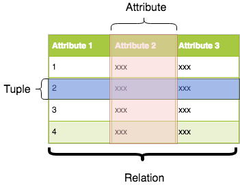

As you can see in the image above, each row represents a structured entity, while each column represents an attribute of that entity. For example, we can define a person as having a last name and a first name (see image below). We can store this information in a table with three columns. One column represents a unique key while the other two columns represent the first and last name. Each row in the table represents a particular person.

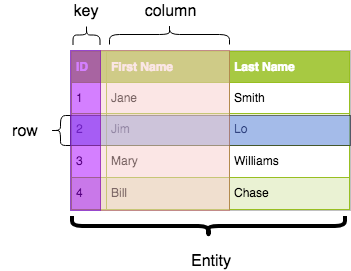

Now let’s say we want to store car information for each person. We can define a second table that stores car information and use the unique keys (i.e. ID and VIN) to associate a person to a car as shown below.

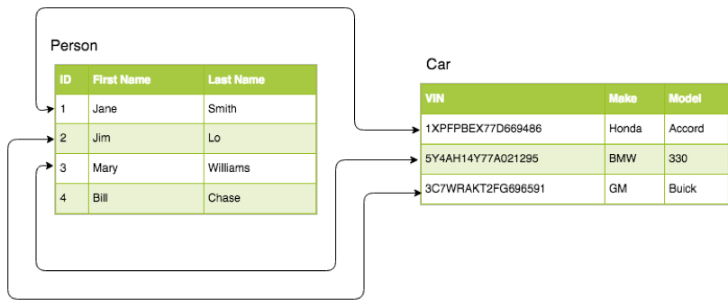

In the image above, notice that we have modelled a 1-to-1 relationship between Person and Car (arrows link one person from table 1 to one car in table 2). What if want to model a many-to-many relationship? A car can have multiple owners and an owner can own multiple cars. We can define a third table, called a **junction** or **association** table to model the many-to-many ownership relationship as seen below. *Junction tables or association tables* *connect two or more tables together by referencing the primary keys of each table participating in a relationship*.

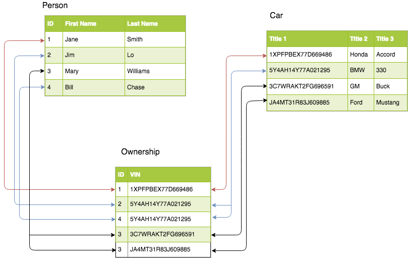

The junction table in the above example takes the key from table 1 (person ID - 1, 2, 3 or 4) and combines it with the ID key from table 2 (the VIN). Notice it shows that Mary owns the GM and the Ford car, while Jim and Bill both own the same BMW. Because the BMW is owned by two people, there are two entries in table 3 for it – one associated with person 2 (Jim) and the other associated with person 4 (Bill).

Designing a well-designed relational database schema to accurately represent real world data takes practice. In addition, we must be aware of the kinds of datastore optimizations we want for our application. In some cases, we want a schema that is optimized to minimize storage space, while in other cases we want to optimize for fast read access or for fast write access. We usually need to make tradeoffs between these.

There are many books and techniques that have been written to help practitioners design relational database schemas. One such technique is **database normalization**. *Database normalization* *defines a set of rules called normalized forms that help reduce data redundancy and improve data integrity*. If you are interested in further reading, see:https://en.wikipedia.org/wiki/Database_normalization). You don't need to know about normalization for extracting data from a database, but it is an essential technique for database designers.

## Structured Query Language (SQL)

Now that we have a method of modelling our data (the relational model), we need a way to query that data. SQL is a declarative language that allows us to express commands in the form of queries to store, manipulate and retrieve data from a relational database.

### CRUD Operations

Any complete language for working with data must support four fundamental operations, often referred to collectively as **CRUD**:

- **C**reate: Add a new record (row) to the database
- **R**ead: Retrieve one or more records from the database, usually subject to some criteria
- **U**pdate: Change the data in one or more existing database records to update them
- **D**elete: Remove one or more records

The SQL syntax defines the following directives to carry out operations:

- **Clauses**: Directives that filter, order and aggregate data
- **Expressions**: Formulas that evaluate to a value
- **Predicates**: Functions that evaluates to either true or false
- **Statements**: Combinations of clauses, expressions and predicates that are used to manage data or schemas by controlling transactions, program flow, connections, sessions, or diagnostics
- **Queries**: Statements that perform CRUD operations

The following diagram illustrates the syntax of a SQL statement.

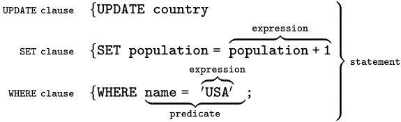

[SQL syntax. Wikipedia. (Public Domain). Retrieved from https://en.wikipedia.org/wiki/SQL_syntax]

### Transactions

Transactions help database systems achieve both data consistency and availability. A **transaction** is a unit of work that can be made up of one or more operations. For example, let’s say I have a datastore that stores a list of names and I want to change each name by capitalizing the first letter. I can define a transaction that is made up of two CRUD operations. I first *READ* the name from the datastore, and then *UPDATE* the datastore with the capitalized name. By combining these two operations into a transaction they become **all of nothing** i.e. they either both successfully execute, or the database is left as it was before the transaction began.

Having transactions available as part of SQL is one of the reasons for its success and ubiquity. It allows, for example, for money to be safely transferred between accounts. There are two steps to this process: remove the money from the first account and add it to the second. By welding these two operations together into a transaction, we can have very high confidence that both parts will either succeed or fail as a unit, avoiding a situation where money is destroyed or created because the first half of the operation succeeded but the second failed for some reason.

### ACID transaction behaviours or properties

For a database management system to be considered "ACID" it must support four behaviours or properties. ACID is an acronym for the four transaction behaviors that have a direct effect on the data consistency and availability of a datastore: Atomicity, Consistency, Isolation and Durability. Datastores that were designed to support the ACID paradigm are focused on keeping the data consistent with each other and the set of integrity constraints specified for that data. (Consistency comes with a performance cost, however. We'll meet other database types soon that put more emphasis on performance at the cost of consistency).

**Atomicity** implies that each transaction is guaranteed to completely succeed or completely fail. Given a transaction with 2 or more operations, if any of the operations fail, any data being altered by the transaction is reset to its initial value as if the transaction were never started. When designing your datastore schema you can define rules that are enforced when executing a transaction. For example, a schema rule can be defined to indicate that all names stored in the datastore must be unique. If a transaction tries to create a name that already exists in the datastore the entire transaction will fail. This ensures the integrity of the data.

**Consistency** ensures that a transaction can only bring the database from one valid state to another, maintaining database invariants (constraints): any data written to the database must be valid according to all defined rules, including constraints, cascades, triggers, and any combination thereof. This prevents database corruption by a transaction that tries to break the rules, but does not guarantee that a transaction is correct.

**Isolation** addresses the possibility of multiple transactions happening at the same time. For example, two different transactions could be writing to the same table row at the same time. Isolation ensures that concurrent execution of transactions leaves the database in the same state that would have been obtained if the transactions were executed sequentially. Without isolation, a transaction could read and use data that has been only partially updated by another concurrent transaction, resulting in corrupted data being returned by a query and/or stored.

**Durability** guarantees that once a transaction has been committed (i.e. a transaction has successfully completed), it will remain committed even in the case of a system failure (e.g., power outage or crash). This means that the updated data must be written to disk before the transaction is considered finished, and done in a way that if a crash occurs in the middle of writing a row the database management system will either complete or back out the changes upon reboot.

Many datastores use locks to process transactions with ACID capabilities. A lock is a flag that prevents data in a table or row from being updated because another transaction has reserved it for update. Consider when two update transactions are handled concurrently by the datastore. A lock on the part of the datastore being updated will be acquired by one of the transactions. The transaction that acquires the lock first is the only transaction that has permission to modify the locked data. The second transaction must wait for the first transaction to complete. Only then will the lock be released and the second transaction can acquire it and proceed. There are various locking strategies that a datastore can utilize. Each strategy has different levels of the tradeoff between data availability and consistency. If you are interested in further reading, see: https://en.wikipedia.org/wiki/Isolation_(database_systems)

# Operational Data Stores and Data Warehouses

Large modern organizations continually collect enormous amounts of data and accumulate it over time. Moreover, this data is spread across different divisions and often different kinds of datastores. The challenge is for organizations to make this data available to be used for business management, analysis and reporting. Datastores used for general sharing and reporting (as opposed to ones dedicated to a specific application) can be thought of as falling into two broad categories: operational data stores and data warehouses.

An **operational data store (ODS)** is a type of database that receives information from different data sources within an organization. It serves as short-term storage that contains the most up-to-date snapshots of business operational data. Organizations use ODSs to perform simple queries, usually on relatively small datasets, to handle daily operational and reporting needs.

In contrast, **data warehouses** provide longer term storage and contain historical data. This provides organizations with a means to run complex, long running queries and keep them separate from operational queries that the ODS's support. If these large complex queries were run on the same datastore as is used for daily operations, it could cause the day-to-day queries to run too slowly to support real-time business use.

## Structuring the contents of data warehouses

To provide a consistent view of the data in a data warehouse, the data is usually organized in a hierarchical grouping of tables called a **star schema**. In this approach there are two specific kinds of data tables that the data is organized into: **fact tables** and **dimension tables**.

Fact tables store values of attributes of an object or business transaction that are measurable like price, height, or quantity sold. Dimension tables store the categories that we'd like to organize the facts into such as product name, retail location or date. This structure is particularly convenient for business queries and aggregations, such as "Show me all the sales in the Western Region in June, along with the total by category".

The following illustrates an example star schema that represents sales information.

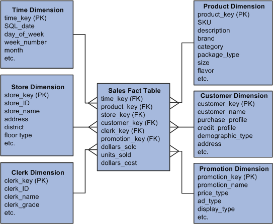

[Star Schema Example, https://docs.oracle.com/cd/E41507_01/epm91pbr3/eng/epm/penw/concept_MultidimensionalWarehouseMDW-9912e0.html]

ODS and data warehouses work together to provide an organizational data solution. The following illustrates a simple architecture showing how this works.

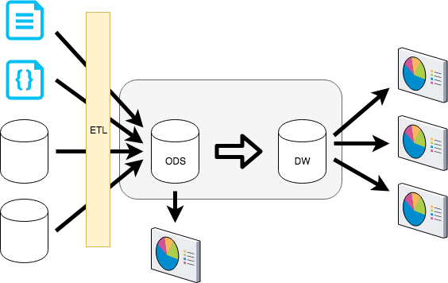

As shown in the image above, the ODS receives data from different sources across different departments. *ETL* *stands for Extract, Transform and Load, a process for transferring data from one data source to another*. The data is kept in the ODS only temporarily so any analysis done using it can only be done on fairly current data. Periodically, the ODS data is archived to a data warehouse store, which supports long-term trend analysis and historical comparisons.

The following table contrasts the properties of data warehouses and operational data stores (ODS):

| Data Warehouse | Operational Data Stores (ODS) |
| --- | --- |
| Long term storage | Short term storage |
| Provides a consistent view of the organizational data | Provides a consistent view of the organizational data |
| Used to run long running complex queries to produce off-line reports | Used to run simple queries on small datasets to provide real-time analysis and reporting |
| Stores historical data | Stores current snapshot of data |
| Receives data from ODS | Receives data from different data sources |
| Data is updated periodically. In some cases, nightly or weekly | Data is frequently updated |

**End of Part 1**

This notebook makes up one part of this module. Now that you have completed this part, please proceed to the next notebook in this module.

If you have any questions, please reach out to your peers using the discussion boards. If you and your peers are unable to come to a suitable conclusion, do not hesitate to reach out to your instructor on the designated discussion board.

# References

- Icons of Progress, IBM. (Public Domain). Retrieve from https://www.ibm.com/ibm/history/ibm100/us/en/icons/reldb/
- Operational data store. SearchOracle. (Public Domain). Retrieved from https://searchoracle.techtarget.com/definition/operational-data-store
- Relational database. Wikipedia. (Public Domain). Retrieved from https://en.wikipedia.org/wiki/Relational_database
- SQL. Wikipedia. (Public Domain). Retrieved from https://en.wikipedia.org/wiki/SQL
- Associative entity. Wikipedia. (Public Domain). Retrieved from https://en.wikipedia.org/wiki/Associative_entity
- SQL syntax. Wikipedia. (Public Domain). Retrieved from https://en.wikipedia.org/wiki/SQL_syntax
- ACID. Wikipedia. (Public Domain). Consistency, Isolation and Durability definition. Retrieved from https://en.wikipedia.org/wiki/ACID_(computer_science)